# wrangle_act

**Gathering Data**

```python
import datetime as dt
import json
import numpy as np
import pandas as pd
import re
import requests
import tweepy
```

Loading Twitter enhanced csv file given

```python
archive = pd.read_csv("twitter-archive-enhanced.csv")

archive.head(2)
```

|  | tweet_id | in_reply_to_status_id | in_reply_to_user_id | timestamp | source | text | retweeted_status_id | retweeted_status_user_id | retweeted_status_timestamp | expanded_urls | rating_numerator | rating_denominator | name | doggo | floofer | pupper | puppo |
| --- | --- | --- | --- | --- | --- | --- | --- | --- | --- | --- | --- | --- | --- | --- | --- | --- | --- |
| 0 | 892420643555336193 | NaN | NaN | 2017-08-01 16:23:56 +0000 | <a href="http://twitter.com/download/iphone" r... | This is Phineas. He's a mystical boy. Only eve... | NaN | NaN | NaN | https://twitter.com/dog_rates/status/892420643... | 13 | 10 | Phineas | None | None | None | None |
| 1 | 892177421306343426 | NaN | NaN | 2017-08-01 00:17:27 +0000 | <a href="http://twitter.com/download/iphone" r... | This is Tilly. She's just checking pup on you.... | NaN | NaN | NaN | https://twitter.com/dog_rates/status/892177421... | 13 | 10 | Tilly | None | None | None | None |

JSON file and twitter API

```python
'''
import tweepy
from tweepy import OAuthHandler
import json
from timeit import default_timer as timer

# Query Twitter API for each tweet in the Twitter archive and save JSON in a text file
# These are hidden to comply with Twitter's API terms and conditions
consumer_key = 'HIDDEN'
consumer_secret = 'HIDDEN'
access_token = 'HIDDEN'
access_secret = 'HIDDEN'

auth = OAuthHandler(consumer_key, consumer_secret)
auth.set_access_token(access_token, access_secret)

api = tweepy.API(auth, wait_on_rate_limit=True)

# NOTE TO STUDENT WITH MOBILE VERIFICATION ISSUES:
# df_1 is a DataFrame with the twitter_archive_enhanced.csv file. You may have to
# change line 17 to match the name of your DataFrame with twitter_archive_enhanced.csv
# NOTE TO REVIEWER: this student had mobile verification issues so the following
# Twitter API code was sent to this student from a Udacity instructor
# Tweet IDs for which to gather additional data via Twitter's API
tweet_ids = df_1.tweet_id.values
len(tweet_ids)

# Query Twitter's API for JSON data for each tweet ID in the Twitter archive
count = 0
fails_dict = {}
start = timer()
# Save each tweet's returned JSON as a new line in a .txt file
with open('tweet_json.txt', 'w') as outfile:
    # This loop will likely take 20-30 minutes to run because of Twitter's rate limit
    for tweet_id in tweet_ids:
        count += 1
        print(str(count) + ": " + str(tweet_id))
        try:
            tweet = api.get_status(tweet_id, tweet_mode='extended')
            print("Success")
            json.dump(tweet._json, outfile)
            outfile.write('\n')
        except tweepy.TweepError as e:
            print("Fail")
            fails_dict[tweet_id] = e
            pass
end = timer()
print(end - start)
print(fails_dict)


'''
```

[output not shown]

```python
#writting the tweet data to json file
with open('tweet-json.txt', 'r') as f:
    twitter_json = pd.read_json(f, lines=True)
    twitter_json = twitter_json[['id','favorite_count','retweet_count']]
twitter_json.head(10)
```

|  | id | favorite_count | retweet_count |
| --- | --- | --- | --- |
| 0 | 892420643555336193 | 39467 | 8853 |
| 1 | 892177421306343426 | 33819 | 6514 |
| 2 | 891815181378084864 | 25461 | 4328 |
| 3 | 891689557279858688 | 42908 | 8964 |
| 4 | 891327558926688256 | 41048 | 9774 |
| 5 | 891087950875897856 | 20562 | 3261 |
| 6 | 890971913173991426 | 12041 | 2158 |
| 7 | 890729181411237888 | 56848 | 16716 |
| 8 | 890609185150312448 | 28226 | 4429 |
| 9 | 890240255349198849 | 32467 | 7711 |

Gathering image predicitons

```python
tsv_url = "https://d17h27t6h515a5.cloudfront.net/topher/2017/August/599fd2ad_image-predictions/image-predictions.tsv"
r = requests.get(tsv_url)

with open(tsv_url.split('/')[-1], mode = 'wb') as file:
    file.write(r.content)

images = pd.read_csv('image-predictions.tsv', sep = '\t')
images.head(2)
```

|  | tweet_id | jpg_url | img_num | p1 | p1_conf | p1_dog | p2 | p2_conf | p2_dog | p3 | p3_conf | p3_dog |
| --- | --- | --- | --- | --- | --- | --- | --- | --- | --- | --- | --- | --- |
| 0 | 666020888022790149 | https://pbs.twimg.com/media/CT4udn0WwAA0aMy.jpg | 1 | Welsh_springer_spaniel | 0.465074 | True | collie | 0.156665 | True | Shetland_sheepdog | 0.061428 | True |
| 1 | 666029285002620928 | https://pbs.twimg.com/media/CT42GRgUYAA5iDo.jpg | 1 | redbone | 0.506826 | True | miniature_pinscher | 0.074192 | True | Rhodesian_ridgeback | 0.072010 | True |

**Assessing data**

**Quality issuess :**

I. Archive

1.Some dogs have 'None' as a name, or 'a', or 'an.'

2.timestamp is an object

3.source column has the HTML tags which are not needed

4.Dataset has duplicated tweets, because it has retweets

5.doggo, pupper,floofer and puppo have values that are the string "None" instead of NaN

6.tweet_id is integer, whereas it is object in json file.

7.Delete columns that won't be used for analysis and are unwanted

8.Some ratings are incorrect

9.Multiple columns for dogtypes, which are not needed

10.Some tweets without images

II.Images

1.p1, p2 and p3 columns have an underscore for multi-word dog breeds

2.p1,p2,p3 also have a lot of invalid data

III.Twitter-Json

1.It is missing some data

**Tidiness issues :**

1.We need to change tweet_id to type int64 in order to merge with the other 2 tables

2.Merge everything in one dataset

3.Make one single column dog stage for doggo, floofer, pupper, puppo columns.

Visual Assesment

```python
archive
```

| tweet_id | in_reply_to_status_id | in_reply_to_user_id | timestamp | source | text | retweeted_status_id | retweeted_status_user_id | retweeted_status_timestamp | expanded_urls | rating_numerator | rating_denominator | name | doggo | floofer | pupper | puppo |
| --- | --- | --- | --- | --- | --- | --- | --- | --- | --- | --- | --- | --- | --- | --- | --- | --- |
| 892420643555336193 | NaN | NaN | 2017-08-01 16:23:56 +0000 | <a href="http://twitter.com/download/iphone" r... | This is Phineas. He's a mystical boy. Only eve... | NaN | NaN | NaN | https://twitter.com/dog_rates/status/892420643... | 13 | 10 | Phineas | None | None | None | None |
| 892177421306343426 | NaN | NaN | 2017-08-01 00:17:27 +0000 | <a href="http://twitter.com/download/iphone" r... | This is Tilly. She's just checking pup on you.... | NaN | NaN | NaN | https://twitter.com/dog_rates/status/892177421... | 13 | 10 | Tilly | None | None | None | None |
| 891815181378084864 | NaN | NaN | 2017-07-31 00:18:03 +0000 | <a href="http://twitter.com/download/iphone" r... | This is Archie. He is a rare Norwegian Pouncin... | NaN | NaN | NaN | https://twitter.com/dog_rates/status/891815181... | 12 | 10 | Archie | None | None | None | None |
| 891689557279858688 | NaN | NaN | 2017-07-30 15:58:51 +0000 | <a href="http://twitter.com/download/iphone" r... | This is Darla. She commenced a snooze mid meal... | NaN | NaN | NaN | https://twitter.com/dog_rates/status/891689557... | 13 | 10 | Darla | None | None | None | None |
| 891327558926688256 | NaN | NaN | 2017-07-29 16:00:24 +0000 | <a href="http://twitter.com/download/iphone" r... | This is Franklin. He would like you to stop ca... | NaN | NaN | NaN | https://twitter.com/dog_rates/status/891327558... | 12 | 10 | Franklin | None | None | None | None |
| 891087950875897856 | NaN | NaN | 2017-07-29 00:08:17 +0000 | <a href="http://twitter.com/download/iphone" r... | Here we have a majestic great white breaching ... | NaN | NaN | NaN | https://twitter.com/dog_rates/status/891087950... | 13 | 10 | None | None | None | None | None |
| 890971913173991426 | NaN | NaN | 2017-07-28 16:27:12 +0000 | <a href="http://twitter.com/download/iphone" r... | Meet Jax. He enjoys ice cream so much he gets ... | NaN | NaN | NaN | https://gofundme.com/ydvmve-surgery-for-jax,ht... | 13 | 10 | Jax | None | None | None | None |
| 890729181411237888 | NaN | NaN | 2017-07-28 00:22:40 +0000 | <a href="http://twitter.com/download/iphone" r... | When you watch your owner call another dog a g... | NaN | NaN | NaN | https://twitter.com/dog_rates/status/890729181... | 13 | 10 | None | None | None | None | None |
| 890609185150312448 | NaN | NaN | 2017-07-27 16:25:51 +0000 | <a href="http://twitter.com/download/iphone" r... | This is Zoey. She doesn't want to be one of th... | NaN | NaN | NaN | https://twitter.com/dog_rates/status/890609185... | 13 | 10 | Zoey | None | None | None | None |
| 890240255349198849 | NaN | NaN | 2017-07-26 15:59:51 +0000 | <a href="http://twitter.com/download/iphone" r... | This is Cassie. She is a college pup. Studying... | NaN | NaN | NaN | https://twitter.com/dog_rates/status/890240255... | 14 | 10 | Cassie | doggo | None | None | None |
| 890006608113172480 | NaN | NaN | 2017-07-26 00:31:25 +0000 | <a href="http://twitter.com/download/iphone" r... | This is Koda. He is a South Australian decksha... | NaN | NaN | NaN | https://twitter.com/dog_rates/status/890006608... | 13 | 10 | Koda | None | None | None | None |
| 889880896479866881 | NaN | NaN | 2017-07-25 16:11:53 +0000 | <a href="http://twitter.com/download/iphone" r... | This is Bruno. He is a service shark. Only get... | NaN | NaN | NaN | https://twitter.com/dog_rates/status/889880896... | 13 | 10 | Bruno | None | None | None | None |
| 889665388333682689 | NaN | NaN | 2017-07-25 01:55:32 +0000 | <a href="http://twitter.com/download/iphone" r... | Here's a puppo that seems to be on the fence a... | NaN | NaN | NaN | https://twitter.com/dog_rates/status/889665388... | 13 | 10 | None | None | None | None | puppo |
| 889638837579907072 | NaN | NaN | 2017-07-25 00:10:02 +0000 | <a href="http://twitter.com/download/iphone" r... | This is Ted. He does his best. Sometimes that'... | NaN | NaN | NaN | https://twitter.com/dog_rates/status/889638837... | 12 | 10 | Ted | None | None | None | None |
| 889531135344209921 | NaN | NaN | 2017-07-24 17:02:04 +0000 | <a href="http://twitter.com/download/iphone" r... | This is Stuart. He's sporting his favorite fan... | NaN | NaN | NaN | https://twitter.com/dog_rates/status/889531135... | 13 | 10 | Stuart | None | None | None | puppo |
| 889278841981685760 | NaN | NaN | 2017-07-24 00:19:32 +0000 | <a href="http://twitter.com/download/iphone" r... | This is Oliver. You're witnessing one of his m... | NaN | NaN | NaN | https://twitter.com/dog_rates/status/889278841... | 13 | 10 | Oliver | None | None | None | None |
| 888917238123831296 | NaN | NaN | 2017-07-23 00:22:39 +0000 | <a href="http://twitter.com/download/iphone" r... | This is Jim. He found a fren. Taught him how t... | NaN | NaN | NaN | https://twitter.com/dog_rates/status/888917238... | 12 | 10 | Jim | None | None | None | None |
| 888804989199671297 | NaN | NaN | 2017-07-22 16:56:37 +0000 | <a href="http://twitter.com/download/iphone" r... | This is Zeke. He has a new stick. Very proud o... | NaN | NaN | NaN | https://twitter.com/dog_rates/status/888804989... | 13 | 10 | Zeke | None | None | None | None |
| 888554962724278272 | NaN | NaN | 2017-07-22 00:23:06 +0000 | <a href="http://twitter.com/download/iphone" r... | This is Ralphus. He's powering up. Attempting ... | NaN | NaN | NaN | https://twitter.com/dog_rates/status/888554962... | 13 | 10 | Ralphus | None | None | None | None |
| 888202515573088257 | NaN | NaN | 2017-07-21 01:02:36 +0000 | <a href="http://twitter.com/download/iphone" r... | RT @dog_rates: This is Canela. She attempted s... | 8.874740e+17 | 4.196984e+09 | 2017-07-19 00:47:34 +0000 | https://twitter.com/dog_rates/status/887473957... | 13 | 10 | Canela | None | None | None | None |
| 888078434458587136 | NaN | NaN | 2017-07-20 16:49:33 +0000 | <a href="http://twitter.com/download/iphone" r... | This is Gerald. He was just told he didn't get... | NaN | NaN | NaN | https://twitter.com/dog_rates/status/888078434... | 12 | 10 | Gerald | None | None | None | None |
| 887705289381826560 | NaN | NaN | 2017-07-19 16:06:48 +0000 | <a href="http://twitter.com/download/iphone" r... | This is Jeffrey. He has a monopoly on the pool... | NaN | NaN | NaN | https://twitter.com/dog_rates/status/887705289... | 13 | 10 | Jeffrey | None | None | None | None |
| 887517139158093824 | NaN | NaN | 2017-07-19 03:39:09 +0000 | <a href="http://twitter.com/download/iphone" r... | I've yet to rate a Venezuelan Hover Wiener. Th... | NaN | NaN | NaN | https://twitter.com/dog_rates/status/887517139... | 14 | 10 | such | None | None | None | None |
| 887473957103951883 | NaN | NaN | 2017-07-19 00:47:34 +0000 | <a href="http://twitter.com/download/iphone" r... | This is Canela. She attempted some fancy porch... | NaN | NaN | NaN | https://twitter.com/dog_rates/status/887473957... | 13 | 10 | Canela | None | None | None | None |
| 887343217045368832 | NaN | NaN | 2017-07-18 16:08:03 +0000 | <a href="http://twitter.com/download/iphone" r... | You may not have known you needed to see this ... | NaN | NaN | NaN | https://twitter.com/dog_rates/status/887343217... | 13 | 10 | None | None | None | None | None |
| 887101392804085760 | NaN | NaN | 2017-07-18 00:07:08 +0000 | <a href="http://twitter.com/download/iphone" r... | This... is a Jubilant Antarctic House Bear. We... | NaN | NaN | NaN | https://twitter.com/dog_rates/status/887101392... | 12 | 10 | None | None | None | None | None |
| 886983233522544640 | NaN | NaN | 2017-07-17 16:17:36 +0000 | <a href="http://twitter.com/download/iphone" r... | This is Maya. She's very shy. Rarely leaves he... | NaN | NaN | NaN | https://twitter.com/dog_rates/status/886983233... | 13 | 10 | Maya | None | None | None | None |
| 886736880519319552 | NaN | NaN | 2017-07-16 23:58:41 +0000 | <a href="http://twitter.com/download/iphone" r... | This is Mingus. He's a wonderful father to his... | NaN | NaN | NaN | https://www.gofundme.com/mingusneedsus,https:/... | 13 | 10 | Mingus | None | None | None | None |
| 886680336477933568 | NaN | NaN | 2017-07-16 20:14:00 +0000 | <a href="http://twitter.com/download/iphone" r... | This is Derek. He's late for a dog meeting. 13... | NaN | NaN | NaN | https://twitter.com/dog_rates/status/886680336... | 13 | 10 | Derek | None | None | None | None |
| 886366144734445568 | NaN | NaN | 2017-07-15 23:25:31 +0000 | <a href="http://twitter.com/download/iphone" r... | This is Roscoe. Another pupper fallen victim t... | NaN | NaN | NaN | https://twitter.com/dog_rates/status/886366144... | 12 | 10 | Roscoe | None | None | pupper | None |
| ... | ... | ... | ... | ... | ... | ... | ... | ... | ... | ... | ... | ... | ... | ... | ... | ... |
| 666411507551481857 | NaN | NaN | 2015-11-17 00:24:19 +0000 | <a href="http://twitter.com/download/iphone" r... | This is quite the dog. Gets really excited whe... | NaN | NaN | NaN | https://twitter.com/dog_rates/status/666411507... | 2 | 10 | quite | None | None | None | None |
| 666407126856765440 | NaN | NaN | 2015-11-17 00:06:54 +0000 | <a href="http://twitter.com/download/iphone" r... | This is a southern Vesuvius bumblegruff. Can d... | NaN | NaN | NaN | https://twitter.com/dog_rates/status/666407126... | 7 | 10 | a | None | None | None | None |
| 666396247373291520 | NaN | NaN | 2015-11-16 23:23:41 +0000 | <a href="http://twitter.com/download/iphone" r... | Oh goodness. A super rare northeast Qdoba kang... | NaN | NaN | NaN | https://twitter.com/dog_rates/status/666396247... | 9 | 10 | None | None | None | None | None |
| 666373753744588802 | NaN | NaN | 2015-11-16 21:54:18 +0000 | <a href="http://twitter.com/download/iphone" r... | Those are sunglasses and a jean jacket. 11/10 ... | NaN | NaN | NaN | https://twitter.com/dog_rates/status/666373753... | 11 | 10 | None | None | None | None | None |
| 666362758909284353 | NaN | NaN | 2015-11-16 21:10:36 +0000 | <a href="http://twitter.com/download/iphone" r... | Unique dog here. Very small. Lives in containe... | NaN | NaN | NaN | https://twitter.com/dog_rates/status/666362758... | 6 | 10 | None | None | None | None | None |
| 666353288456101888 | NaN | NaN | 2015-11-16 20:32:58 +0000 | <a href="http://twitter.com/download/iphone" r... | Here we have a mixed Asiago from the Galápagos... | NaN | NaN | NaN | https://twitter.com/dog_rates/status/666353288... | 8 | 10 | None | None | None | None | None |
| 666345417576210432 | NaN | NaN | 2015-11-16 20:01:42 +0000 | <a href="http://twitter.com/download/iphone" r... | Look at this jokester thinking seat belt laws ... | NaN | NaN | NaN | https://twitter.com/dog_rates/status/666345417... | 10 | 10 | None | None | None | None | None |
| 666337882303524864 | NaN | NaN | 2015-11-16 19:31:45 +0000 | <a href="http://twitter.com/download/iphone" r... | This is an extremely rare horned Parthenon. No... | NaN | NaN | NaN | https://twitter.com/dog_rates/status/666337882... | 9 | 10 | an | None | None | None | None |
| 666293911632134144 | NaN | NaN | 2015-11-16 16:37:02 +0000 | <a href="http://twitter.com/download/iphone" r... | This is a funny dog. Weird toes. Won't come do... | NaN | NaN | NaN | https://twitter.com/dog_rates/status/666293911... | 3 | 10 | a | None | None | None | None |
| 666287406224695296 | NaN | NaN | 2015-11-16 16:11:11 +0000 | <a href="http://twitter.com/download/iphone" r... | This is an Albanian 3 1/2 legged Episcopalian... | NaN | NaN | NaN | https://twitter.com/dog_rates/status/666287406... | 1 | 2 | an | None | None | None | None |
| 666273097616637952 | NaN | NaN | 2015-11-16 15:14:19 +0000 | <a href="http://twitter.com/download/iphone" r... | Can take selfies 11/10 https://t.co/ws2AMaNwPW | NaN | NaN | NaN | https://twitter.com/dog_rates/status/666273097... | 11 | 10 | None | None | None | None | None |
| 666268910803644416 | NaN | NaN | 2015-11-16 14:57:41 +0000 | <a href="http://twitter.com/download/iphone" r... | Very concerned about fellow dog trapped in com... | NaN | NaN | NaN | https://twitter.com/dog_rates/status/666268910... | 10 | 10 | None | None | None | None | None |
| 666104133288665088 | NaN | NaN | 2015-11-16 04:02:55 +0000 | <a href="http://twitter.com/download/iphone" r... | Not familiar with this breed. No tail (weird).... | NaN | NaN | NaN | https://twitter.com/dog_rates/status/666104133... | 1 | 10 | None | None | None | None | None |
| 666102155909144576 | NaN | NaN | 2015-11-16 03:55:04 +0000 | <a href="http://twitter.com/download/iphone" r... | Oh my. Here you are seeing an Adobe Setter giv... | NaN | NaN | NaN | https://twitter.com/dog_rates/status/666102155... | 11 | 10 | None | None | None | None | None |
| 666099513787052032 | NaN | NaN | 2015-11-16 03:44:34 +0000 | <a href="http://twitter.com/download/iphone" r... | Can stand on stump for what seems like a while... | NaN | NaN | NaN | https://twitter.com/dog_rates/status/666099513... | 8 | 10 | None | None | None | None | None |
| 666094000022159362 | NaN | NaN | 2015-11-16 03:22:39 +0000 | <a href="http://twitter.com/download/iphone" r... | This appears to be a Mongolian Presbyterian mi... | NaN | NaN | NaN | https://twitter.com/dog_rates/status/666094000... | 9 | 10 | None | None | None | None | None |
| 666082916733198337 | NaN | NaN | 2015-11-16 02:38:37 +0000 | <a href="http://twitter.com/download/iphone" r... | Here we have a well-established sunblockerspan... | NaN | NaN | NaN | https://twitter.com/dog_rates/status/666082916... | 6 | 10 | None | None | None | None | None |
| 666073100786774016 | NaN | NaN | 2015-11-16 01:59:36 +0000 | <a href="http://twitter.com/download/iphone" r... | Let's hope this flight isn't Malaysian (lol). ... | NaN | NaN | NaN | https://twitter.com/dog_rates/status/666073100... | 10 | 10 | None | None | None | None | None |
| 666071193221509120 | NaN | NaN | 2015-11-16 01:52:02 +0000 | <a href="http://twitter.com/download/iphone" r... | Here we have a northern speckled Rhododendron.... | NaN | NaN | NaN | https://twitter.com/dog_rates/status/666071193... | 9 | 10 | None | None | None | None | None |
| 666063827256086533 | NaN | NaN | 2015-11-16 01:22:45 +0000 | <a href="http://twitter.com/download/iphone" r... | This is the happiest dog you will ever see. Ve... | NaN | NaN | NaN | https://twitter.com/dog_rates/status/666063827... | 10 | 10 | the | None | None | None | None |
| 666058600524156928 | NaN | NaN | 2015-11-16 01:01:59 +0000 | <a href="http://twitter.com/download/iphone" r... | Here is the Rand Paul of retrievers folks! He'... | NaN | NaN | NaN | https://twitter.com/dog_rates/status/666058600... | 8 | 10 | the | None | None | None | None |
| 666057090499244032 | NaN | NaN | 2015-11-16 00:55:59 +0000 | <a href="http://twitter.com/download/iphone" r... | My oh my. This is a rare blond Canadian terrie... | NaN | NaN | NaN | https://twitter.com/dog_rates/status/666057090... | 9 | 10 | a | None | None | None | None |
| 666055525042405380 | NaN | NaN | 2015-11-16 00:49:46 +0000 | <a href="http://twitter.com/download/iphone" r... | Here is a Siberian heavily armored polar bear ... | NaN | NaN | NaN | https://twitter.com/dog_rates/status/666055525... | 10 | 10 | a | None | None | None | None |
| 666051853826850816 | NaN | NaN | 2015-11-16 00:35:11 +0000 | <a href="http://twitter.com/download/iphone" r... | This is an odd dog. Hard on the outside but lo... | NaN | NaN | NaN | https://twitter.com/dog_rates/status/666051853... | 2 | 10 | an | None | None | None | None |
| 666050758794694657 | NaN | NaN | 2015-11-16 00:30:50 +0000 | <a href="http://twitter.com/download/iphone" r... | This is a truly beautiful English Wilson Staff... | NaN | NaN | NaN | https://twitter.com/dog_rates/status/666050758... | 10 | 10 | a | None | None | None | None |
| 666049248165822465 | NaN | NaN | 2015-11-16 00:24:50 +0000 | <a href="http://twitter.com/download/iphone" r... | Here we have a 1949 1st generation vulpix. Enj... | NaN | NaN | NaN | https://twitter.com/dog_rates/status/666049248... | 5 | 10 | None | None | None | None | None |
| 666044226329800704 | NaN | NaN | 2015-11-16 00:04:52 +0000 | <a href="http://twitter.com/download/iphone" r... | This is a purebred Piers Morgan. Loves to Netf... | NaN | NaN | NaN | https://twitter.com/dog_rates/status/666044226... | 6 | 10 | a | None | None | None | None |
| 666033412701032449 | NaN | NaN | 2015-11-15 23:21:54 +0000 | <a href="http://twitter.com/download/iphone" r... | Here is a very happy pup. Big fan of well-main... | NaN | NaN | NaN | https://twitter.com/dog_rates/status/666033412... | 9 | 10 | a | None | None | None | None |
| 666029285002620928 | NaN | NaN | 2015-11-15 23:05:30 +0000 | <a href="http://twitter.com/download/iphone" r... | This is a western brown Mitsubishi terrier. Up... | NaN | NaN | NaN | https://twitter.com/dog_rates/status/666029285... | 7 | 10 | a | None | None | None | None |
| 666020888022790149 | NaN | NaN | 2015-11-15 22:32:08 +0000 | <a href="http://twitter.com/download/iphone" r... | Here we have a Japanese Irish Setter. Lost eye... | NaN | NaN | NaN | https://twitter.com/dog_rates/status/666020888... | 8 | 10 | None | None | None | None | None |

2356 rows × 16 columns

```python
twitter_json
```

|  | id | favorite_count | retweet_count |
| --- | --- | --- | --- |
| 0 | 892420643555336193 | 39467 | 8853 |
| 1 | 892177421306343426 | 33819 | 6514 |
| 2 | 891815181378084864 | 25461 | 4328 |
| 3 | 891689557279858688 | 42908 | 8964 |
| 4 | 891327558926688256 | 41048 | 9774 |
| 5 | 891087950875897856 | 20562 | 3261 |
| 6 | 890971913173991426 | 12041 | 2158 |
| 7 | 890729181411237888 | 56848 | 16716 |
| 8 | 890609185150312448 | 28226 | 4429 |
| 9 | 890240255349198849 | 32467 | 7711 |
| 10 | 890006608113172480 | 31166 | 7624 |
| 11 | 889880896479866881 | 28268 | 5156 |
| 12 | 889665388333682689 | 38818 | 8538 |
| 13 | 889638837579907072 | 27672 | 4735 |
| 14 | 889531135344209921 | 15359 | 2321 |
| 15 | 889278841981685760 | 25652 | 5637 |
| 16 | 888917238123831296 | 29611 | 4709 |
| 17 | 888804989199671297 | 26080 | 4559 |
| 18 | 888554962724278272 | 20290 | 3732 |
| 19 | 888078434458587136 | 22201 | 3653 |
| 20 | 887705289381826560 | 30779 | 5609 |
| 21 | 887517139158093824 | 46959 | 12082 |
| 22 | 887473957103951883 | 69871 | 18781 |
| 23 | 887343217045368832 | 34222 | 10737 |
| 24 | 887101392804085760 | 31061 | 6167 |
| 25 | 886983233522544640 | 35859 | 8084 |
| 26 | 886736880519319552 | 12306 | 3443 |
| 27 | 886680336477933568 | 22798 | 4610 |
| 28 | 886366144734445568 | 21524 | 3316 |
| 29 | 886267009285017600 | 117 | 4 |
| ... | ... | ... | ... |
| 2324 | 666411507551481857 | 459 | 339 |
| 2325 | 666407126856765440 | 113 | 44 |
| 2326 | 666396247373291520 | 172 | 92 |
| 2327 | 666373753744588802 | 194 | 100 |
| 2328 | 666362758909284353 | 804 | 595 |
| 2329 | 666353288456101888 | 229 | 77 |
| 2330 | 666345417576210432 | 307 | 146 |
| 2331 | 666337882303524864 | 204 | 96 |
| 2332 | 666293911632134144 | 522 | 368 |
| 2333 | 666287406224695296 | 152 | 71 |
| 2334 | 666273097616637952 | 184 | 82 |
| 2335 | 666268910803644416 | 108 | 37 |
| 2336 | 666104133288665088 | 14765 | 6871 |
| 2337 | 666102155909144576 | 81 | 16 |
| 2338 | 666099513787052032 | 164 | 73 |
| 2339 | 666094000022159362 | 169 | 79 |
| 2340 | 666082916733198337 | 121 | 47 |
| 2341 | 666073100786774016 | 335 | 174 |
| 2342 | 666071193221509120 | 154 | 67 |
| 2343 | 666063827256086533 | 496 | 232 |
| 2344 | 666058600524156928 | 115 | 61 |
| 2345 | 666057090499244032 | 304 | 146 |
| 2346 | 666055525042405380 | 448 | 261 |
| 2347 | 666051853826850816 | 1253 | 879 |
| 2348 | 666050758794694657 | 136 | 60 |
| 2349 | 666049248165822465 | 111 | 41 |
| 2350 | 666044226329800704 | 311 | 147 |
| 2351 | 666033412701032449 | 128 | 47 |
| 2352 | 666029285002620928 | 132 | 48 |
| 2353 | 666020888022790149 | 2535 | 532 |

2354 rows × 3 columns

```python
images
```

|  | tweet_id | jpg_url | img_num | p1 | p1_conf | p1_dog | p2 | p2_conf | p2_dog | p3 | p3_conf | p3_dog |
| --- | --- | --- | --- | --- | --- | --- | --- | --- | --- | --- | --- | --- |
| 0 | 666020888022790149 | https://pbs.twimg.com/media/CT4udn0WwAA0aMy.jpg | 1 | Welsh_springer_spaniel | 0.465074 | True | collie | 0.156665 | True | Shetland_sheepdog | 0.061428 | True |
| 1 | 666029285002620928 | https://pbs.twimg.com/media/CT42GRgUYAA5iDo.jpg | 1 | redbone | 0.506826 | True | miniature_pinscher | 0.074192 | True | Rhodesian_ridgeback | 0.072010 | True |
| 2 | 666033412701032449 | https://pbs.twimg.com/media/CT4521TWwAEvMyu.jpg | 1 | German_shepherd | 0.596461 | True | malinois | 0.138584 | True | bloodhound | 0.116197 | True |
| 3 | 666044226329800704 | https://pbs.twimg.com/media/CT5Dr8HUEAA-lEu.jpg | 1 | Rhodesian_ridgeback | 0.408143 | True | redbone | 0.360687 | True | miniature_pinscher | 0.222752 | True |
| 4 | 666049248165822465 | https://pbs.twimg.com/media/CT5IQmsXIAAKY4A.jpg | 1 | miniature_pinscher | 0.560311 | True | Rottweiler | 0.243682 | True | Doberman | 0.154629 | True |
| 5 | 666050758794694657 | https://pbs.twimg.com/media/CT5Jof1WUAEuVxN.jpg | 1 | Bernese_mountain_dog | 0.651137 | True | English_springer | 0.263788 | True | Greater_Swiss_Mountain_dog | 0.016199 | True |
| 6 | 666051853826850816 | https://pbs.twimg.com/media/CT5KoJ1WoAAJash.jpg | 1 | box_turtle | 0.933012 | False | mud_turtle | 0.045885 | False | terrapin | 0.017885 | False |
| 7 | 666055525042405380 | https://pbs.twimg.com/media/CT5N9tpXIAAifs1.jpg | 1 | chow | 0.692517 | True | Tibetan_mastiff | 0.058279 | True | fur_coat | 0.054449 | False |
| 8 | 666057090499244032 | https://pbs.twimg.com/media/CT5PY90WoAAQGLo.jpg | 1 | shopping_cart | 0.962465 | False | shopping_basket | 0.014594 | False | golden_retriever | 0.007959 | True |
| 9 | 666058600524156928 | https://pbs.twimg.com/media/CT5Qw94XAAA_2dP.jpg | 1 | miniature_poodle | 0.201493 | True | komondor | 0.192305 | True | soft-coated_wheaten_terrier | 0.082086 | True |
| 10 | 666063827256086533 | https://pbs.twimg.com/media/CT5Vg_wXIAAXfnj.jpg | 1 | golden_retriever | 0.775930 | True | Tibetan_mastiff | 0.093718 | True | Labrador_retriever | 0.072427 | True |
| 11 | 666071193221509120 | https://pbs.twimg.com/media/CT5cN_3WEAAlOoZ.jpg | 1 | Gordon_setter | 0.503672 | True | Yorkshire_terrier | 0.174201 | True | Pekinese | 0.109454 | True |
| 12 | 666073100786774016 | https://pbs.twimg.com/media/CT5d9DZXAAALcwe.jpg | 1 | Walker_hound | 0.260857 | True | English_foxhound | 0.175382 | True | Ibizan_hound | 0.097471 | True |
| 13 | 666082916733198337 | https://pbs.twimg.com/media/CT5m4VGWEAAtKc8.jpg | 1 | pug | 0.489814 | True | bull_mastiff | 0.404722 | True | French_bulldog | 0.048960 | True |
| 14 | 666094000022159362 | https://pbs.twimg.com/media/CT5w9gUW4AAsBNN.jpg | 1 | bloodhound | 0.195217 | True | German_shepherd | 0.078260 | True | malinois | 0.075628 | True |
| 15 | 666099513787052032 | https://pbs.twimg.com/media/CT51-JJUEAA6hV8.jpg | 1 | Lhasa | 0.582330 | True | Shih-Tzu | 0.166192 | True | Dandie_Dinmont | 0.089688 | True |
| 16 | 666102155909144576 | https://pbs.twimg.com/media/CT54YGiWUAEZnoK.jpg | 1 | English_setter | 0.298617 | True | Newfoundland | 0.149842 | True | borzoi | 0.133649 | True |
| 17 | 666104133288665088 | https://pbs.twimg.com/media/CT56LSZWoAAlJj2.jpg | 1 | hen | 0.965932 | False | cock | 0.033919 | False | partridge | 0.000052 | False |
| 18 | 666268910803644416 | https://pbs.twimg.com/media/CT8QCd1WEAADXws.jpg | 1 | desktop_computer | 0.086502 | False | desk | 0.085547 | False | bookcase | 0.079480 | False |
| 19 | 666273097616637952 | https://pbs.twimg.com/media/CT8T1mtUwAA3aqm.jpg | 1 | Italian_greyhound | 0.176053 | True | toy_terrier | 0.111884 | True | basenji | 0.111152 | True |
| 20 | 666287406224695296 | https://pbs.twimg.com/media/CT8g3BpUEAAuFjg.jpg | 1 | Maltese_dog | 0.857531 | True | toy_poodle | 0.063064 | True | miniature_poodle | 0.025581 | True |
| 21 | 666293911632134144 | https://pbs.twimg.com/media/CT8mx7KW4AEQu8N.jpg | 1 | three-toed_sloth | 0.914671 | False | otter | 0.015250 | False | great_grey_owl | 0.013207 | False |
| 22 | 666337882303524864 | https://pbs.twimg.com/media/CT9OwFIWEAMuRje.jpg | 1 | ox | 0.416669 | False | Newfoundland | 0.278407 | True | groenendael | 0.102643 | True |
| 23 | 666345417576210432 | https://pbs.twimg.com/media/CT9Vn7PWoAA_ZCM.jpg | 1 | golden_retriever | 0.858744 | True | Chesapeake_Bay_retriever | 0.054787 | True | Labrador_retriever | 0.014241 | True |
| 24 | 666353288456101888 | https://pbs.twimg.com/media/CT9cx0tUEAAhNN_.jpg | 1 | malamute | 0.336874 | True | Siberian_husky | 0.147655 | True | Eskimo_dog | 0.093412 | True |
| 25 | 666362758909284353 | https://pbs.twimg.com/media/CT9lXGsUcAAyUFt.jpg | 1 | guinea_pig | 0.996496 | False | skunk | 0.002402 | False | hamster | 0.000461 | False |
| 26 | 666373753744588802 | https://pbs.twimg.com/media/CT9vZEYWUAAlZ05.jpg | 1 | soft-coated_wheaten_terrier | 0.326467 | True | Afghan_hound | 0.259551 | True | briard | 0.206803 | True |
| 27 | 666396247373291520 | https://pbs.twimg.com/media/CT-D2ZHWIAA3gK1.jpg | 1 | Chihuahua | 0.978108 | True | toy_terrier | 0.009397 | True | papillon | 0.004577 | True |
| 28 | 666407126856765440 | https://pbs.twimg.com/media/CT-NvwmW4AAugGZ.jpg | 1 | black-and-tan_coonhound | 0.529139 | True | bloodhound | 0.244220 | True | flat-coated_retriever | 0.173810 | True |
| 29 | 666411507551481857 | https://pbs.twimg.com/media/CT-RugiWIAELEaq.jpg | 1 | coho | 0.404640 | False | barracouta | 0.271485 | False | gar | 0.189945 | False |
| ... | ... | ... | ... | ... | ... | ... | ... | ... | ... | ... | ... | ... |
| 2045 | 886366144734445568 | https://pbs.twimg.com/media/DE0BTnQUwAApKEH.jpg | 1 | French_bulldog | 0.999201 | True | Chihuahua | 0.000361 | True | Boston_bull | 0.000076 | True |
| 2046 | 886680336477933568 | https://pbs.twimg.com/media/DE4fEDzWAAAyHMM.jpg | 1 | convertible | 0.738995 | False | sports_car | 0.139952 | False | car_wheel | 0.044173 | False |
| 2047 | 886736880519319552 | https://pbs.twimg.com/media/DE5Se8FXcAAJFx4.jpg | 1 | kuvasz | 0.309706 | True | Great_Pyrenees | 0.186136 | True | Dandie_Dinmont | 0.086346 | True |
| 2048 | 886983233522544640 | https://pbs.twimg.com/media/DE8yicJW0AAAvBJ.jpg | 2 | Chihuahua | 0.793469 | True | toy_terrier | 0.143528 | True | can_opener | 0.032253 | False |
| 2049 | 887101392804085760 | https://pbs.twimg.com/media/DE-eAq6UwAA-jaE.jpg | 1 | Samoyed | 0.733942 | True | Eskimo_dog | 0.035029 | True | Staffordshire_bullterrier | 0.029705 | True |
| 2050 | 887343217045368832 | https://pbs.twimg.com/ext_tw_video_thumb/88734... | 1 | Mexican_hairless | 0.330741 | True | sea_lion | 0.275645 | False | Weimaraner | 0.134203 | True |
| 2051 | 887473957103951883 | https://pbs.twimg.com/media/DFDw2tyUQAAAFke.jpg | 2 | Pembroke | 0.809197 | True | Rhodesian_ridgeback | 0.054950 | True | beagle | 0.038915 | True |
| 2052 | 887517139158093824 | https://pbs.twimg.com/ext_tw_video_thumb/88751... | 1 | limousine | 0.130432 | False | tow_truck | 0.029175 | False | shopping_cart | 0.026321 | False |
| 2053 | 887705289381826560 | https://pbs.twimg.com/media/DFHDQBbXgAEqY7t.jpg | 1 | basset | 0.821664 | True | redbone | 0.087582 | True | Weimaraner | 0.026236 | True |
| 2054 | 888078434458587136 | https://pbs.twimg.com/media/DFMWn56WsAAkA7B.jpg | 1 | French_bulldog | 0.995026 | True | pug | 0.000932 | True | bull_mastiff | 0.000903 | True |
| 2055 | 888202515573088257 | https://pbs.twimg.com/media/DFDw2tyUQAAAFke.jpg | 2 | Pembroke | 0.809197 | True | Rhodesian_ridgeback | 0.054950 | True | beagle | 0.038915 | True |
| 2056 | 888554962724278272 | https://pbs.twimg.com/media/DFTH_O-UQAACu20.jpg | 3 | Siberian_husky | 0.700377 | True | Eskimo_dog | 0.166511 | True | malamute | 0.111411 | True |
| 2057 | 888804989199671297 | https://pbs.twimg.com/media/DFWra-3VYAA2piG.jpg | 1 | golden_retriever | 0.469760 | True | Labrador_retriever | 0.184172 | True | English_setter | 0.073482 | True |
| 2058 | 888917238123831296 | https://pbs.twimg.com/media/DFYRgsOUQAARGhO.jpg | 1 | golden_retriever | 0.714719 | True | Tibetan_mastiff | 0.120184 | True | Labrador_retriever | 0.105506 | True |
| 2059 | 889278841981685760 | https://pbs.twimg.com/ext_tw_video_thumb/88927... | 1 | whippet | 0.626152 | True | borzoi | 0.194742 | True | Saluki | 0.027351 | True |
| 2060 | 889531135344209921 | https://pbs.twimg.com/media/DFg_2PVW0AEHN3p.jpg | 1 | golden_retriever | 0.953442 | True | Labrador_retriever | 0.013834 | True | redbone | 0.007958 | True |
| 2061 | 889638837579907072 | https://pbs.twimg.com/media/DFihzFfXsAYGDPR.jpg | 1 | French_bulldog | 0.991650 | True | boxer | 0.002129 | True | Staffordshire_bullterrier | 0.001498 | True |
| 2062 | 889665388333682689 | https://pbs.twimg.com/media/DFi579UWsAAatzw.jpg | 1 | Pembroke | 0.966327 | True | Cardigan | 0.027356 | True | basenji | 0.004633 | True |
| 2063 | 889880896479866881 | https://pbs.twimg.com/media/DFl99B1WsAITKsg.jpg | 1 | French_bulldog | 0.377417 | True | Labrador_retriever | 0.151317 | True | muzzle | 0.082981 | False |
| 2064 | 890006608113172480 | https://pbs.twimg.com/media/DFnwSY4WAAAMliS.jpg | 1 | Samoyed | 0.957979 | True | Pomeranian | 0.013884 | True | chow | 0.008167 | True |
| 2065 | 890240255349198849 | https://pbs.twimg.com/media/DFrEyVuW0AAO3t9.jpg | 1 | Pembroke | 0.511319 | True | Cardigan | 0.451038 | True | Chihuahua | 0.029248 | True |
| 2066 | 890609185150312448 | https://pbs.twimg.com/media/DFwUU__XcAEpyXI.jpg | 1 | Irish_terrier | 0.487574 | True | Irish_setter | 0.193054 | True | Chesapeake_Bay_retriever | 0.118184 | True |
| 2067 | 890729181411237888 | https://pbs.twimg.com/media/DFyBahAVwAAhUTd.jpg | 2 | Pomeranian | 0.566142 | True | Eskimo_dog | 0.178406 | True | Pembroke | 0.076507 | True |
| 2068 | 890971913173991426 | https://pbs.twimg.com/media/DF1eOmZXUAALUcq.jpg | 1 | Appenzeller | 0.341703 | True | Border_collie | 0.199287 | True | ice_lolly | 0.193548 | False |
| 2069 | 891087950875897856 | https://pbs.twimg.com/media/DF3HwyEWsAABqE6.jpg | 1 | Chesapeake_Bay_retriever | 0.425595 | True | Irish_terrier | 0.116317 | True | Indian_elephant | 0.076902 | False |
| 2070 | 891327558926688256 | https://pbs.twimg.com/media/DF6hr6BUMAAzZgT.jpg | 2 | basset | 0.555712 | True | English_springer | 0.225770 | True | German_short-haired_pointer | 0.175219 | True |
| 2071 | 891689557279858688 | https://pbs.twimg.com/media/DF_q7IAWsAEuuN8.jpg | 1 | paper_towel | 0.170278 | False | Labrador_retriever | 0.168086 | True | spatula | 0.040836 | False |
| 2072 | 891815181378084864 | https://pbs.twimg.com/media/DGBdLU1WsAANxJ9.jpg | 1 | Chihuahua | 0.716012 | True | malamute | 0.078253 | True | kelpie | 0.031379 | True |
| 2073 | 892177421306343426 | https://pbs.twimg.com/media/DGGmoV4XsAAUL6n.jpg | 1 | Chihuahua | 0.323581 | True | Pekinese | 0.090647 | True | papillon | 0.068957 | True |
| 2074 | 892420643555336193 | https://pbs.twimg.com/media/DGKD1-bXoAAIAUK.jpg | 1 | orange | 0.097049 | False | bagel | 0.085851 | False | banana | 0.076110 | False |

2075 rows × 12 columns

Programmatic assesment

```python
archive.info
```

[output not shown]

[output cut: 562 more lines]

```python
archive.name.value_counts()
```

```
None         745
a             55
Charlie       12
Oliver        11
Cooper        11
Lucy          11
Tucker        10
Penny         10
Lola          10
Bo             9
Winston        9
the            8
Sadie          8
Toby           7
Bailey         7
Buddy          7
an             7
Daisy          7
Scout          6
Rusty          6
Koda           6
Leo            6
Milo           6
Stanley        6
Jax            6
Jack           6
Dave           6
Oscar          6
Bella          6
very           5
            ...
Stuart         1
Aiden          1
Gin            1
Bowie          1
Jonah          1
Winifred       1
Laela          1
Batdog         1
Stephanus      1
Obie           1
Pumpkin        1
Stormy         1
Mason          1
Iroh           1
Stu            1
Ben            1
Brutus         1
Devón          1
Rufio          1
Rupert         1
Farfle         1
Bodie          1
Marlee         1
Cupid          1
Ralphus        1
Wesley         1
Kulet          1
Noah           1
Duchess        1
Rhino          1
Name: name, Length: 957, dtype: int64
```

```python
archive.rating_denominator.value_counts()
```

```
10     2333
11        3
50        3
80        2
20        2
2         1
16        1
40        1
70        1
15        1
90        1
110       1
120       1
130       1
150       1
170       1
7         1
0         1
Name: rating_denominator, dtype: int64
```

```python
archive.rating_numerator.value_counts()
```

```
12      558
11      464
10      461
13      351
9       158
8       102
7        55
14       54
5        37
6        32
3        19
4        17
1         9
2         9
420       2
```

[output cut: 26 more lines]

```python
archive.describe
```

[output not shown]

[output cut: 562 more lines]

```python
archive.head(5)
```

| tweet_id | in_reply_to_status_id | in_reply_to_user_id | timestamp | source | text | retweeted_status_id | retweeted_status_user_id | retweeted_status_timestamp | expanded_urls | rating_numerator | rating_denominator | name | doggo | floofer | pupper | puppo |
| --- | --- | --- | --- | --- | --- | --- | --- | --- | --- | --- | --- | --- | --- | --- | --- | --- |
| 892420643555336193 | NaN | NaN | 2017-08-01 16:23:56 +0000 | <a href="http://twitter.com/download/iphone" r... | This is Phineas. He's a mystical boy. Only eve... | NaN | NaN | NaN | https://twitter.com/dog_rates/status/892420643... | 13 | 10 | Phineas | None | None | None | None |
| 892177421306343426 | NaN | NaN | 2017-08-01 00:17:27 +0000 | <a href="http://twitter.com/download/iphone" r... | This is Tilly. She's just checking pup on you.... | NaN | NaN | NaN | https://twitter.com/dog_rates/status/892177421... | 13 | 10 | Tilly | None | None | None | None |
| 891815181378084864 | NaN | NaN | 2017-07-31 00:18:03 +0000 | <a href="http://twitter.com/download/iphone" r... | This is Archie. He is a rare Norwegian Pouncin... | NaN | NaN | NaN | https://twitter.com/dog_rates/status/891815181... | 12 | 10 | Archie | None | None | None | None |
| 891689557279858688 | NaN | NaN | 2017-07-30 15:58:51 +0000 | <a href="http://twitter.com/download/iphone" r... | This is Darla. She commenced a snooze mid meal... | NaN | NaN | NaN | https://twitter.com/dog_rates/status/891689557... | 13 | 10 | Darla | None | None | None | None |
| 891327558926688256 | NaN | NaN | 2017-07-29 16:00:24 +0000 | <a href="http://twitter.com/download/iphone" r... | This is Franklin. He would like you to stop ca... | NaN | NaN | NaN | https://twitter.com/dog_rates/status/891327558... | 12 | 10 | Franklin | None | None | None | None |

```python
sum(archive['tweet_id'].duplicated())
```

```
0
```

```python
archive['name'].value_counts()
```

```
None         745
a             55
Charlie       12
Oliver        11
Cooper        11
Lucy          11
Tucker        10
Penny         10
Lola          10
Bo             9
Winston        9
the            8
Sadie          8
Toby           7
Bailey         7
Buddy          7
an             7
Daisy          7
Scout          6
Rusty          6
Koda           6
Leo            6
Milo           6
Stanley        6
Jax            6
Jack           6
Dave           6
Oscar          6
Bella          6
very           5
            ...
Stuart         1
Aiden          1
Gin            1
Bowie          1
Jonah          1
Winifred       1
Laela          1
Batdog         1
Stephanus      1
Obie           1
Pumpkin        1
Stormy         1
Mason          1
Iroh           1
Stu            1
Ben            1
Brutus         1
Devón          1
Rufio          1
Rupert         1
Farfle         1
Bodie          1
Marlee         1
Cupid          1
Ralphus        1
Wesley         1
Kulet          1
Noah           1
Duchess        1
Rhino          1
Name: name, Length: 957, dtype: int64
```

```python
images.sample(5)
```

|  | tweet_id | jpg_url | img_num | p1 | p1_conf | p1_dog | p2 | p2_conf | p2_dog | p3 | p3_conf | p3_dog |
| --- | --- | --- | --- | --- | --- | --- | --- | --- | --- | --- | --- | --- |
| 1952 | 863553081350529029 | https://pbs.twimg.com/ext_tw_video_thumb/86355... | 1 | Eskimo_dog | 0.413330 | True | malamute | 0.347646 | True | Siberian_husky | 0.149536 | True |
| 957 | 705442520700944385 | https://pbs.twimg.com/media/Cco8OmOXIAE0aCu.jpg | 1 | Great_Pyrenees | 0.309106 | True | kuvasz | 0.224556 | True | seat_belt | 0.202100 | False |
| 2064 | 890006608113172480 | https://pbs.twimg.com/media/DFnwSY4WAAAMliS.jpg | 1 | Samoyed | 0.957979 | True | Pomeranian | 0.013884 | True | chow | 0.008167 | True |
| 98 | 667766675769573376 | https://pbs.twimg.com/media/CURiQMnUAAAPT2M.jpg | 1 | fire_engine | 0.883493 | False | tow_truck | 0.074734 | False | jeep | 0.012773 | False |
| 1186 | 739238157791694849 | https://pbs.twimg.com/ext_tw_video_thumb/73923... | 1 | Eskimo_dog | 0.503372 | True | Siberian_husky | 0.390413 | True | malamute | 0.080901 | True |

```python
images.info()
```

```
<class 'pandas.core.frame.DataFrame'>
RangeIndex: 2075 entries, 0 to 2074
Data columns (total 12 columns):
tweet_id    2075 non-null int64
jpg_url     2075 non-null object
img_num     2075 non-null int64
p1          2075 non-null object
p1_conf     2075 non-null float64
p1_dog      2075 non-null bool
p2          2075 non-null object
p2_conf     2075 non-null float64
p2_dog      2075 non-null bool
p3          2075 non-null object
p3_conf     2075 non-null float64
p3_dog      2075 non-null bool
dtypes: bool(3), float64(3), int64(2), object(4)
memory usage: 152.1+ KB
```

```python
images['p1'].value_counts()
```

```
golden_retriever             150
Labrador_retriever           100
Pembroke                      89
Chihuahua                     83
pug                           57
chow                          44
Samoyed                       43
toy_poodle                    39
Pomeranian                    38
malamute                      30
cocker_spaniel                30
French_bulldog                26
Chesapeake_Bay_retriever      23
miniature_pinscher            23
seat_belt                     22
Siberian_husky                20
German_shepherd               20
Staffordshire_bullterrier     20
Cardigan                      19
web_site                      19
Maltese_dog                   18
teddy                         18
Eskimo_dog                    18
beagle                        18
Shetland_sheepdog             18
Rottweiler                    17
Lakeland_terrier              17
Shih-Tzu                      17
Italian_greyhound             16
kuvasz                        16
                            ...
giant_panda                    1
long-horned_beetle             1
microwave                      1
hammer                         1
loupe                          1
wild_boar                      1
pool_table                     1
platypus                       1
hay                            1
traffic_light                  1
dining_table                   1
shopping_basket                1
binoculars                     1
panpipe                        1
timber_wolf                    1
studio_couch                   1
lion                           1
harp                           1
hummingbird                    1
electric_fan                   1
handkerchief                   1
skunk                          1
ibex                           1
sunglasses                     1
earthstar                      1
walking_stick                  1
cup                            1
coho                           1
bannister                      1
swab                           1
Name: p1, Length: 378, dtype: int64
```

```python
images['p2'].value_counts()
```

```
Labrador_retriever                104
golden_retriever                   92
Cardigan                           73
Chihuahua                          44
Pomeranian                         42
Chesapeake_Bay_retriever           41
French_bulldog                     41
toy_poodle                         37
cocker_spaniel                     34
Siberian_husky                     33
miniature_poodle                   33
beagle                             28
collie                             27
Pembroke                           27
Eskimo_dog                         27
kuvasz                             26
Italian_greyhound                  22
Pekinese                           21
American_Staffordshire_terrier     21
Samoyed                            20
miniature_pinscher                 20
malinois                           20
toy_terrier                        20
chow                               20
Norwegian_elkhound                 19
Boston_bull                        19
Staffordshire_bullterrier          18
Irish_terrier                      17
pug                                17
Shih-Tzu                           16
                                 ...
wombat                              1
Gila_monster                        1
standard_schnauzer                  1
mud_turtle                          1
wood_rabbit                         1
menu                                1
canoe                               1
spotlight                           1
dumbbell                            1
wallaby                             1
television                          1
sombrero                            1
table_lamp                          1
komondor                            1
sunglass                            1
snowmobile                          1
sea_urchin                          1
sock                                1
goose                               1
knee_pad                            1
patio                               1
cliff                               1
indri                               1
bearskin                            1
rule                                1
snorkel                             1
purse                               1
sweatshirt                          1
oxygen_mask                         1
sliding_door                        1
Name: p2, Length: 405, dtype: int64
```

```python
images['p3'].value_counts()
```

```
Labrador_retriever                79
Chihuahua                         58
golden_retriever                  48
Eskimo_dog                        38
kelpie                            35
kuvasz                            34
Staffordshire_bullterrier         32
chow                              32
cocker_spaniel                    31
beagle                            31
Pomeranian                        29
Pekinese                          29
toy_poodle                        29
Great_Pyrenees                    27
Chesapeake_Bay_retriever          27
Pembroke                          27
French_bulldog                    26
malamute                          26
American_Staffordshire_terrier    24
pug                               23
Cardigan                          23
basenji                           21
bull_mastiff                      20
toy_terrier                       20
Siberian_husky                    19
Shetland_sheepdog                 17
Boston_bull                       17
boxer                             16
Lakeland_terrier                  16
doormat                           16
                                  ..
African_chameleon                  1
mink                               1
rhinoceros_beetle                  1
consomme                           1
sunglass                           1
Windsor_tie                        1
shovel                             1
beach_wagon                        1
loggerhead                         1
assault_rifle                      1
crayfish                           1
bulletproof_vest                   1
pajama                             1
mushroom                           1
standard_schnauzer                 1
mountain_tent                      1
great_grey_owl                     1
soap_dispenser                     1
hand_blower                        1
chickadee                          1
power_drill                        1
goose                              1
bell_cote                          1
marmot                             1
cliff                              1
vacuum                             1
mongoose                           1
maze                               1
plastic_bag                        1
wombat                             1
Name: p3, Length: 408, dtype: int64
```

```python
twitter_json.info
```

```
<bound method DataFrame.info of                       id  favorite_count  retweet_count
0     892420643555336193           39467           8853
1     892177421306343426           33819           6514
2     891815181378084864           25461           4328
3     891689557279858688           42908           8964
4     891327558926688256           41048           9774
5     891087950875897856           20562           3261
6     890971913173991426           12041           2158
7     890729181411237888           56848          16716
8     890609185150312448           28226           4429
9     890240255349198849           32467           7711
10    890006608113172480           31166           7624
11    889880896479866881           28268           5156
12    889665388333682689           38818           8538
13    889638837579907072           27672           4735
```

[output cut: 49 more lines]

```python
twitter_json.describe
```

[output not shown]

```python
twitter_json.favorite_count.mean()
```

```
8080.9685641461347
```

**Cleaning data**

Copying the data

```python
#copying the data
archive_clean = archive.copy()
images_clean = images.copy()
twitter_json_clean = twitter_json.copy()
```

Tidiness issue

1. Merging into one master dataset

Define :

Merging all the datasets into one, by first renaming the id column in the json file to tweet_id, then converting it to int datatype before merging

Code:

```python
#renaming the id column for merging
twitter_json_clean.rename(columns = {'id':'tweet_id'}, inplace = True)
twitter_json_clean.head(5)
```

|  | tweet_id | favorite_count | retweet_count |
| --- | --- | --- | --- |
| 0 | 892420643555336193 | 39467 | 8853 |
| 1 | 892177421306343426 | 33819 | 6514 |
| 2 | 891815181378084864 | 25461 | 4328 |
| 3 | 891689557279858688 | 42908 | 8964 |
| 4 | 891327558926688256 | 41048 | 9774 |

```python
#coverting tweet_id to int for merging
twitter_json_clean['tweet_id'] = twitter_json_clean['tweet_id'].astype(int)

#test
twitter_json_clean['tweet_id'].dtypes
```

```
dtype('int64')
```

```python
from functools import reduce
dfs = [archive_clean, images_clean, twitter_json_clean]
twitter = reduce(lambda left,right: pd.merge(left,right,on='tweet_id'), dfs)
```

Test:

```python
#test
twitter.head(5)
```

|  | tweet_id | in_reply_to_status_id | in_reply_to_user_id | timestamp | source | text | retweeted_status_id | retweeted_status_user_id | retweeted_status_timestamp | expanded_urls | ... | p1_conf | p1_dog | p2 | p2_conf | p2_dog | p3 | p3_conf | p3_dog | favorite_count | retweet_count |
| --- | --- | --- | --- | --- | --- | --- | --- | --- | --- | --- | --- | --- | --- | --- | --- | --- | --- | --- | --- | --- | --- |
| 0 | 892420643555336193 | NaN | NaN | 2017-08-01 16:23:56 +0000 | <a href="http://twitter.com/download/iphone" r... | This is Phineas. He's a mystical boy. Only eve... | NaN | NaN | NaN | https://twitter.com/dog_rates/status/892420643... | ... | 0.097049 | False | bagel | 0.085851 | False | banana | 0.076110 | False | 39467 | 8853 |
| 1 | 892177421306343426 | NaN | NaN | 2017-08-01 00:17:27 +0000 | <a href="http://twitter.com/download/iphone" r... | This is Tilly. She's just checking pup on you.... | NaN | NaN | NaN | https://twitter.com/dog_rates/status/892177421... | ... | 0.323581 | True | Pekinese | 0.090647 | True | papillon | 0.068957 | True | 33819 | 6514 |
| 2 | 891815181378084864 | NaN | NaN | 2017-07-31 00:18:03 +0000 | <a href="http://twitter.com/download/iphone" r... | This is Archie. He is a rare Norwegian Pouncin... | NaN | NaN | NaN | https://twitter.com/dog_rates/status/891815181... | ... | 0.716012 | True | malamute | 0.078253 | True | kelpie | 0.031379 | True | 25461 | 4328 |
| 3 | 891689557279858688 | NaN | NaN | 2017-07-30 15:58:51 +0000 | <a href="http://twitter.com/download/iphone" r... | This is Darla. She commenced a snooze mid meal... | NaN | NaN | NaN | https://twitter.com/dog_rates/status/891689557... | ... | 0.170278 | False | Labrador_retriever | 0.168086 | True | spatula | 0.040836 | False | 42908 | 8964 |
| 4 | 891327558926688256 | NaN | NaN | 2017-07-29 16:00:24 +0000 | <a href="http://twitter.com/download/iphone" r... | This is Franklin. He would like you to stop ca... | NaN | NaN | NaN | https://twitter.com/dog_rates/status/891327558... | ... | 0.555712 | True | English_springer | 0.225770 | True | German_short-haired_pointer | 0.175219 | True | 41048 | 9774 |

5 rows × 30 columns

2.Single column dog stage floofer, pupper, puppo columns

Define :

One single column named dog stage for the floofer,puper,puppo and doggo columns

Code :

```python
twitter.doggo.replace('None', '', inplace=True)
twitter.floofer.replace('None', '', inplace=True)
twitter.pupper.replace('None', '', inplace=True)
twitter.puppo.replace('None', '', inplace=True)
```

Test :

```python
twitter['stage'] = twitter.doggo + twitter.floofer + twitter.pupper + twitter.puppo
```

```python
twitter['stage']
```

```
0
1
2
3
4
5
6
7
8
9        doggo
10
11
12       puppo
13
14       puppo
15
16
17
18
19
20
21
22
23
24
25
26
27
28      pupper
29
         ...
2043
2044
2045
2046
2047
2048
2049
2050
2051
2052
2053
2054
2055
2056
2057
2058
2059
2060
2061
2062
2063
2064
2065
2066
2067
2068
2069
2070
2071
2072
Name: stage, Length: 2073, dtype: object
```

Code to replace multiple dog stages

```python
twitter.loc[twitter.stage == 'doggopupper', 'stage'] = 'doggo,pupper'
twitter.loc[twitter.stage == 'doggopuppo', 'stage'] = 'doggo,puppo'
twitter.loc[twitter.stage == 'doggofloofer', 'stage'] = 'doggo,floofer'
twitter.loc[twitter.stage == 'flooferpupper', 'stage'] = 'floofer,pupper'
twitter.loc[twitter.stage == 'flooferpuppo', 'stage'] = 'floofer,puppo'
twitter.loc[twitter.stage == 'flooferdoggo', 'stage'] = 'floofer,doggo'
twitter.loc[twitter.stage == 'pupperdoggo', 'stage'] = 'pupper.doggo'
twitter.loc[twitter.stage == 'pupperpuppo', 'stage'] = 'pupper,puppo'
twitter.loc[twitter.stage == 'pupperfloofer', 'stage'] = 'pupper,floofer'
twitter.loc[twitter.stage == 'puppopupper', 'stage'] = 'puppo,pupper'
twitter.loc[twitter.stage == 'puppodoggo', 'stage'] = 'puppo,doggo'
twitter.loc[twitter.stage == 'puppofloofer', 'stage'] = 'puppo,floofer'
```

Test : Note : 1753 are the empty rows, kept it empty for analysis

```python
twitter['stage'].value_counts()
```

```
                 1753
pupper            210
doggo              67
puppo              23
doggo,pupper       11
floofer             7
doggo,floofer       1
doggo,puppo         1
Name: stage, dtype: int64
```

Quality issue

1.Drop columns not needed

Define: Dropping columns which are not needed for our analysis

Code:

```python
#find the column names of archive_clean
print(list(archive_clean))

#dropping columns not needed
archive_clean = archive_clean.drop(['source', 'in_reply_to_status_id',
                                                    'in_reply_to_user_id',
                                                        'expanded_urls'], 1)
```

```
['tweet_id', 'in_reply_to_status_id', 'in_reply_to_user_id', 'timestamp', 'source', 'text', 'retweeted_status_id', 'retweeted_status_user_id', 'retweeted_status_timestamp', 'expanded_urls', 'rating_numerator', 'rating_denominator', 'name', 'doggo', 'floofer', 'pupper', 'puppo']
```

Test:

```python
archive_clean
```

|  | tweet_id | timestamp | text | rating_numerator | rating_denominator | name | doggo | floofer | pupper | puppo |
| --- | --- | --- | --- | --- | --- | --- | --- | --- | --- | --- |
| 0 | 892420643555336193 | 2017-08-01 16:23:56 +0000 | This is Phineas. He's a mystical boy. Only eve... | 13 | 10 | Phineas | None | None | None | None |
| 1 | 892177421306343426 | 2017-08-01 00:17:27 +0000 | This is Tilly. She's just checking pup on you.... | 13 | 10 | Tilly | None | None | None | None |
| 2 | 891815181378084864 | 2017-07-31 00:18:03 +0000 | This is Archie. He is a rare Norwegian Pouncin... | 12 | 10 | Archie | None | None | None | None |
| 3 | 891689557279858688 | 2017-07-30 15:58:51 +0000 | This is Darla. She commenced a snooze mid meal... | 13 | 10 | Darla | None | None | None | None |
| 4 | 891327558926688256 | 2017-07-29 16:00:24 +0000 | This is Franklin. He would like you to stop ca... | 12 | 10 | Franklin | None | None | None | None |
| 5 | 891087950875897856 | 2017-07-29 00:08:17 +0000 | Here we have a majestic great white breaching ... | 13 | 10 | None | None | None | None | None |
| 6 | 890971913173991426 | 2017-07-28 16:27:12 +0000 | Meet Jax. He enjoys ice cream so much he gets ... | 13 | 10 | Jax | None | None | None | None |
| 7 | 890729181411237888 | 2017-07-28 00:22:40 +0000 | When you watch your owner call another dog a g... | 13 | 10 | None | None | None | None | None |
| 8 | 890609185150312448 | 2017-07-27 16:25:51 +0000 | This is Zoey. She doesn't want to be one of th... | 13 | 10 | Zoey | None | None | None | None |
| 9 | 890240255349198849 | 2017-07-26 15:59:51 +0000 | This is Cassie. She is a college pup. Studying... | 14 | 10 | Cassie | doggo | None | None | None |
| 10 | 890006608113172480 | 2017-07-26 00:31:25 +0000 | This is Koda. He is a South Australian decksha... | 13 | 10 | Koda | None | None | None | None |
| 11 | 889880896479866881 | 2017-07-25 16:11:53 +0000 | This is Bruno. He is a service shark. Only get... | 13 | 10 | Bruno | None | None | None | None |
| 12 | 889665388333682689 | 2017-07-25 01:55:32 +0000 | Here's a puppo that seems to be on the fence a... | 13 | 10 | None | None | None | None | puppo |
| 13 | 889638837579907072 | 2017-07-25 00:10:02 +0000 | This is Ted. He does his best. Sometimes that'... | 12 | 10 | Ted | None | None | None | None |
| 14 | 889531135344209921 | 2017-07-24 17:02:04 +0000 | This is Stuart. He's sporting his favorite fan... | 13 | 10 | Stuart | None | None | None | puppo |
| 15 | 889278841981685760 | 2017-07-24 00:19:32 +0000 | This is Oliver. You're witnessing one of his m... | 13 | 10 | Oliver | None | None | None | None |
| 16 | 888917238123831296 | 2017-07-23 00:22:39 +0000 | This is Jim. He found a fren. Taught him how t... | 12 | 10 | Jim | None | None | None | None |
| 17 | 888804989199671297 | 2017-07-22 16:56:37 +0000 | This is Zeke. He has a new stick. Very proud o... | 13 | 10 | Zeke | None | None | None | None |
| 18 | 888554962724278272 | 2017-07-22 00:23:06 +0000 | This is Ralphus. He's powering up. Attempting ... | 13 | 10 | Ralphus | None | None | None | None |
| 19 | 888202515573088257 | 2017-07-21 01:02:36 +0000 | RT @dog_rates: This is Canela. She attempted s... | 13 | 10 | Canela | None | None | None | None |
| 20 | 888078434458587136 | 2017-07-20 16:49:33 +0000 | This is Gerald. He was just told he didn't get... | 12 | 10 | Gerald | None | None | None | None |
| 21 | 887705289381826560 | 2017-07-19 16:06:48 +0000 | This is Jeffrey. He has a monopoly on the pool... | 13 | 10 | Jeffrey | None | None | None | None |
| 22 | 887517139158093824 | 2017-07-19 03:39:09 +0000 | I've yet to rate a Venezuelan Hover Wiener. Th... | 14 | 10 | such | None | None | None | None |
| 23 | 887473957103951883 | 2017-07-19 00:47:34 +0000 | This is Canela. She attempted some fancy porch... | 13 | 10 | Canela | None | None | None | None |
| 24 | 887343217045368832 | 2017-07-18 16:08:03 +0000 | You may not have known you needed to see this ... | 13 | 10 | None | None | None | None | None |
| 25 | 887101392804085760 | 2017-07-18 00:07:08 +0000 | This... is a Jubilant Antarctic House Bear. We... | 12 | 10 | None | None | None | None | None |
| 26 | 886983233522544640 | 2017-07-17 16:17:36 +0000 | This is Maya. She's very shy. Rarely leaves he... | 13 | 10 | Maya | None | None | None | None |
| 27 | 886736880519319552 | 2017-07-16 23:58:41 +0000 | This is Mingus. He's a wonderful father to his... | 13 | 10 | Mingus | None | None | None | None |
| 28 | 886680336477933568 | 2017-07-16 20:14:00 +0000 | This is Derek. He's late for a dog meeting. 13... | 13 | 10 | Derek | None | None | None | None |
| 29 | 886366144734445568 | 2017-07-15 23:25:31 +0000 | This is Roscoe. Another pupper fallen victim t... | 12 | 10 | Roscoe | None | None | pupper | None |
| ... | ... | ... | ... | ... | ... | ... | ... | ... | ... | ... |
| 2326 | 666411507551481857 | 2015-11-17 00:24:19 +0000 | This is quite the dog. Gets really excited whe... | 2 | 10 | quite | None | None | None | None |
| 2327 | 666407126856765440 | 2015-11-17 00:06:54 +0000 | This is a southern Vesuvius bumblegruff. Can d... | 7 | 10 | a | None | None | None | None |
| 2328 | 666396247373291520 | 2015-11-16 23:23:41 +0000 | Oh goodness. A super rare northeast Qdoba kang... | 9 | 10 | None | None | None | None | None |
| 2329 | 666373753744588802 | 2015-11-16 21:54:18 +0000 | Those are sunglasses and a jean jacket. 11/10 ... | 11 | 10 | None | None | None | None | None |
| 2330 | 666362758909284353 | 2015-11-16 21:10:36 +0000 | Unique dog here. Very small. Lives in containe... | 6 | 10 | None | None | None | None | None |
| 2331 | 666353288456101888 | 2015-11-16 20:32:58 +0000 | Here we have a mixed Asiago from the Galápagos... | 8 | 10 | None | None | None | None | None |
| 2332 | 666345417576210432 | 2015-11-16 20:01:42 +0000 | Look at this jokester thinking seat belt laws ... | 10 | 10 | None | None | None | None | None |
| 2333 | 666337882303524864 | 2015-11-16 19:31:45 +0000 | This is an extremely rare horned Parthenon. No... | 9 | 10 | an | None | None | None | None |
| 2334 | 666293911632134144 | 2015-11-16 16:37:02 +0000 | This is a funny dog. Weird toes. Won't come do... | 3 | 10 | a | None | None | None | None |
| 2335 | 666287406224695296 | 2015-11-16 16:11:11 +0000 | This is an Albanian 3 1/2 legged Episcopalian... | 1 | 2 | an | None | None | None | None |
| 2336 | 666273097616637952 | 2015-11-16 15:14:19 +0000 | Can take selfies 11/10 https://t.co/ws2AMaNwPW | 11 | 10 | None | None | None | None | None |
| 2337 | 666268910803644416 | 2015-11-16 14:57:41 +0000 | Very concerned about fellow dog trapped in com... | 10 | 10 | None | None | None | None | None |
| 2338 | 666104133288665088 | 2015-11-16 04:02:55 +0000 | Not familiar with this breed. No tail (weird).... | 1 | 10 | None | None | None | None | None |
| 2339 | 666102155909144576 | 2015-11-16 03:55:04 +0000 | Oh my. Here you are seeing an Adobe Setter giv... | 11 | 10 | None | None | None | None | None |
| 2340 | 666099513787052032 | 2015-11-16 03:44:34 +0000 | Can stand on stump for what seems like a while... | 8 | 10 | None | None | None | None | None |
| 2341 | 666094000022159362 | 2015-11-16 03:22:39 +0000 | This appears to be a Mongolian Presbyterian mi... | 9 | 10 | None | None | None | None | None |
| 2342 | 666082916733198337 | 2015-11-16 02:38:37 +0000 | Here we have a well-established sunblockerspan... | 6 | 10 | None | None | None | None | None |
| 2343 | 666073100786774016 | 2015-11-16 01:59:36 +0000 | Let's hope this flight isn't Malaysian (lol). ... | 10 | 10 | None | None | None | None | None |
| 2344 | 666071193221509120 | 2015-11-16 01:52:02 +0000 | Here we have a northern speckled Rhododendron.... | 9 | 10 | None | None | None | None | None |
| 2345 | 666063827256086533 | 2015-11-16 01:22:45 +0000 | This is the happiest dog you will ever see. Ve... | 10 | 10 | the | None | None | None | None |
| 2346 | 666058600524156928 | 2015-11-16 01:01:59 +0000 | Here is the Rand Paul of retrievers folks! He'... | 8 | 10 | the | None | None | None | None |
| 2347 | 666057090499244032 | 2015-11-16 00:55:59 +0000 | My oh my. This is a rare blond Canadian terrie... | 9 | 10 | a | None | None | None | None |
| 2348 | 666055525042405380 | 2015-11-16 00:49:46 +0000 | Here is a Siberian heavily armored polar bear ... | 10 | 10 | a | None | None | None | None |
| 2349 | 666051853826850816 | 2015-11-16 00:35:11 +0000 | This is an odd dog. Hard on the outside but lo... | 2 | 10 | an | None | None | None | None |
| 2350 | 666050758794694657 | 2015-11-16 00:30:50 +0000 | This is a truly beautiful English Wilson Staff... | 10 | 10 | a | None | None | None | None |
| 2351 | 666049248165822465 | 2015-11-16 00:24:50 +0000 | Here we have a 1949 1st generation vulpix. Enj... | 5 | 10 | None | None | None | None | None |
| 2352 | 666044226329800704 | 2015-11-16 00:04:52 +0000 | This is a purebred Piers Morgan. Loves to Netf... | 6 | 10 | a | None | None | None | None |
| 2353 | 666033412701032449 | 2015-11-15 23:21:54 +0000 | Here is a very happy pup. Big fan of well-main... | 9 | 10 | a | None | None | None | None |
| 2354 | 666029285002620928 | 2015-11-15 23:05:30 +0000 | This is a western brown Mitsubishi terrier. Up... | 7 | 10 | a | None | None | None | None |
| 2355 | 666020888022790149 | 2015-11-15 22:32:08 +0000 | Here we have a Japanese Irish Setter. Lost eye... | 8 | 10 | None | None | None | None | None |

2356 rows × 10 columns

2.Fix timestamp column

Define: Remove timezone information from timestamp column and then change it to datetime object

Code:

```python
# Removing the time zone information from 'timestamp' column
twitter['timestamp'] = twitter['timestamp'].str.slice(start=0, stop=-6)
```

```python
# Changing the 'timestamp' column to a datetime object
twitter['timestamp'] = pd.to_datetime(twitter['timestamp'], format = "%Y-%m-%d %H:%M:%S")
```

Test:

```python
# Test
twitter.info()
```

```
<class 'pandas.core.frame.DataFrame'>
Int64Index: 2073 entries, 0 to 2072
Data columns (total 30 columns):
tweet_id                      2073 non-null int64
in_reply_to_status_id         23 non-null float64
in_reply_to_user_id           23 non-null float64
timestamp                     2073 non-null datetime64[ns]
source                        2073 non-null object
text                          2073 non-null object
retweeted_status_id           79 non-null float64
retweeted_status_user_id      79 non-null float64
retweeted_status_timestamp    79 non-null object
expanded_urls                 2073 non-null object
rating_numerator              2073 non-null int64
rating_denominator            2073 non-null int64
name                          2073 non-null object
doggo                         2073 non-null object
floofer                       2073 non-null object
pupper                        2073 non-null object
puppo                         2073 non-null object
jpg_url                       2073 non-null object
img_num                       2073 non-null int64
p1                            2073 non-null object
p1_conf                       2073 non-null float64
p1_dog                        2073 non-null bool
p2                            2073 non-null object
p2_conf                       2073 non-null float64
p2_dog                        2073 non-null bool
p3                            2073 non-null object
p3_conf                       2073 non-null float64
p3_dog                        2073 non-null bool
favorite_count                2073 non-null int64
retweet_count                 2073 non-null int64
dtypes: bool(3), datetime64[ns](1), float64(7), int64(6), object(13)
memory usage: 459.5+ KB
```

3.Replace none names

Define: Replace all nones in the name column to NaN

Code:

```python
lowercase_names = []
for row in twitter['name']:
    if row[0].islower() and row not in lowercase_names:
        lowercase_names.append(row)
print(lowercase_names)
```

```
['such', 'a', 'quite', 'one', 'incredibly', 'an', 'very', 'just', 'my', 'not', 'his', 'getting', 'this', 'unacceptable', 'all', 'infuriating', 'the', 'actually', 'by', 'officially', 'light', 'space']
```

```python
# Replace all 'None's with a NaN
twitter['name'].replace('None',
                        np.nan,
                       inplace = True)
#Replace all lowercase_names to Nan
twitter['name'].replace(lowercase_names,
                        np.nan,
                       inplace = True)
```

Test:

```python
#test
twitter['name'].value_counts()
```

```
Charlie     11
Penny       10
Lucy        10
Tucker      10
Oliver      10
Cooper      10
Winston      8
Sadie        8
Bo           8
Lola         8
Toby         7
Daisy        7
Dave         6
Milo         6
Rusty        6
Bella        6
Bailey       6
Jax          6
Koda         6
Scout        6
Stanley      6
Alfie        5
Louis        5
Leo          5
Buddy        5
Oscar        5
Larry        5
Chester      5
Archie       4
Maggie       4
            ..
Sunshine     1
Doobert      1
Ole          1
Karma        1
Tom          1
Gin          1
Mauve        1
Chuq         1
Nida         1
Trevith      1
Kayla        1
Jay          1
Sonny        1
Sobe         1
Tonks        1
Smiley       1
Mason        1
Fletcher     1
Crumpet      1
Biden        1
Stewie       1
Terrance     1
Tupawc       1
Harry        1
Simba        1
Cannon       1
Amélie       1
Jazzy        1
Pluto        1
Marvin       1
Name: name, Length: 913, dtype: int64
```

4.fix rating

Code:

```python
# Calulating the value of 'rating'
twitter['rating_numerator'] = twitter['rating_numerator'].astype(float)
twitter['rating_denominator'] = twitter['rating_denominator'].astype(float)
import re

ratings_decimals_text = []
ratings_decimals_index = []
ratings_decimals = []

for i, text in twitter['text'].iteritems():
    if bool(re.search('\d+\.\d+\/\d+', text)):
        ratings_decimals_text.append(text)
        ratings_decimals_index.append(i)
        ratings_decimals.append(re.search('\d+\.\d+', text).group())

# Printing the ratings with decimals
ratings_decimals_text
```

```
['This is Bella. She hopes her smile made you smile. If not, she is also offering you her favorite monkey. 13.5/10 https://t.co/qjrljjt948',
 "This is Logan, the Chow who lived. He solemnly swears he's up to lots of good. H*ckin magical af 9.75/10 https://t.co/yBO5wuqaPS",
 "This is Sophie. She's a Jubilant Bush Pupper. Super h*ckin rare. Appears at random just to smile at the locals. 11.27/10 would smile back https://t.co/QFaUiIHxHq",
 'Here we have uncovered an entire battalion of holiday puppers. Average of 11.26/10 https://t.co/eNm2S6p9BD']
```

```python
#Now we convert the above decimal ratings to float
twitter.loc[ratings_decimals_index[0],'rating_numerator'] = float(ratings_decimals[0])
twitter.loc[ratings_decimals_index[1],'rating_numerator'] = float(ratings_decimals[1])
twitter.loc[ratings_decimals_index[2],'rating_numerator'] = float(ratings_decimals[2])
twitter.loc[ratings_decimals_index[3],'rating_numerator'] = float(ratings_decimals[3])
```

Test:

```python
#test
twitter.head(1)
twitter.loc[40]
```

[output not shown]

5.Single Colum for all dog types

Define: Create one single column for all dog breeds using the image data

Code :

```python
twitter['dog_breed'] = 'None'

for i, row in twitter.iterrows():

    if row.p1_dog:
        twitter.set_value(i, 'dog_breed', row.p1)
    elif row.p2_dog and row.rating_numerator >= 10:
        twitter.set_value(i, 'dog_breed', row.p2)
    elif row.p3_dog and row.rating_numerator >= 10:
        twitter.set_value(i, 'dog_breed', row.p3)
    else:
        twitter.set_value(i, 'dog_breed', 'None')
```

Test :

```python
#test
twitter['dog_breed'].value_counts()
```

```
None                          380
golden_retriever              171
Labrador_retriever            112
Pembroke                       94
Chihuahua                      89
pug                            63
toy_poodle                     50
chow                           49
Samoyed                        46
Pomeranian                     40
malamute                       34
cocker_spaniel                 34
French_bulldog                 31
Chesapeake_Bay_retriever       29
miniature_pinscher             24
Staffordshire_bullterrier      22
German_shepherd                21
Cardigan                       21
Eskimo_dog                     20
beagle                         20
Siberian_husky                 20
Maltese_dog                    19
Shetland_sheepdog              19
Rottweiler                     18
Shih-Tzu                       18
kuvasz                         18
Italian_greyhound              17
Lakeland_terrier               17
basset                         16
schipperke                     15
                             ...
Tibetan_terrier                 4
Welsh_springer_spaniel          4
Gordon_setter                   4
Afghan_hound                    4
giant_schnauzer                 4
Saluki                          4
Greater_Swiss_Mountain_dog      3
Scottish_deerhound              3
komondor                        3
Irish_water_spaniel             3
curly-coated_retriever          3
Leonberg                        3
cairn                           3
briard                          3
Brabancon_griffon               3
groenendael                     2
black-and-tan_coonhound         2
Australian_terrier              2
Sussex_spaniel                  2
Appenzeller                     2
toy_terrier                     2
wire-haired_fox_terrier         2
Bouvier_des_Flandres            1
Scotch_terrier                  1
Japanese_spaniel                1
EntleBucher                     1
standard_schnauzer              1
Irish_wolfhound                 1
clumber                         1
silky_terrier                   1
Name: dog_breed, Length: 114, dtype: int64
```

6.Removing tweets without images

Define: Not null to remove imageless tweets

Code:

```python
# removing the tweets without images
twitter = twitter[pd.notnull(twitter['jpg_url'])]
```

[output not shown]

Test:

```python
twitter['jpg_url']
```

```
0         https://pbs.twimg.com/media/DGKD1-bXoAAIAUK.jpg
1         https://pbs.twimg.com/media/DGGmoV4XsAAUL6n.jpg
2         https://pbs.twimg.com/media/DGBdLU1WsAANxJ9.jpg
3         https://pbs.twimg.com/media/DF_q7IAWsAEuuN8.jpg
4         https://pbs.twimg.com/media/DF6hr6BUMAAzZgT.jpg
5         https://pbs.twimg.com/media/DF3HwyEWsAABqE6.jpg
6         https://pbs.twimg.com/media/DF1eOmZXUAALUcq.jpg
7         https://pbs.twimg.com/media/DFyBahAVwAAhUTd.jpg
8         https://pbs.twimg.com/media/DFwUU__XcAEpyXI.jpg
9         https://pbs.twimg.com/media/DFrEyVuW0AAO3t9.jpg
10        https://pbs.twimg.com/media/DFnwSY4WAAAMliS.jpg
11        https://pbs.twimg.com/media/DFl99B1WsAITKsg.jpg
12        https://pbs.twimg.com/media/DFi579UWsAAatzw.jpg
13        https://pbs.twimg.com/media/DFihzFfXsAYGDPR.jpg
14        https://pbs.twimg.com/media/DFg_2PVW0AEHN3p.jpg
```

[output cut: 47 more lines]

7.Removing retweets

Define: Removing retweets as they are not needed

Code:

```python
# removing retweets
#Keep the columns where retweeted_status_id is NaN
twitter = twitter[np.isnan(twitter.retweeted_status_id)]
twitter.shape[0]
```

```
1994
```

```python
twitter = twitter.drop(['retweeted_status_id', 'retweeted_status_user_id', 'retweeted_status_timestamp'], axis=1)
```

Test :

```python
twitter.columns
```

[output not shown]

8.Changing tweet_id datatype

Define: We change the tweet_id to string datatype to enable string related functions in the future

Code:

```python
#changing tweet_id to string
twitter['tweet_id'] = twitter['tweet_id'].astype(str)
```

Test:

```python
twitter.info()
```

[output not shown]

**Analyse and Visualise**

Storing the cleaned data into a master csv file

```python
# Storing the new twitter df to a new csv file
twitter.to_csv('twitter_archive_master.csv', encoding='utf-8', index=False)
```

```python
import datetime
import matplotlib.pyplot as plt
%matplotlib inline
import seaborn as sns
```

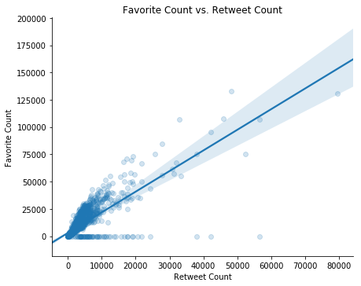

```python
sns.lmplot(x="retweet_count",
           y="favorite_count",
           data=twitter,
           size = 5,
           aspect=1.3,
           scatter_kws={'alpha':1/5});

plt.title('Favorite Count vs. Retweet Count');
plt.xlabel('Retweet Count');
plt.ylabel('Favorite Count');
```

We can see that there is a positive correlation in the above plot between favourite and retweet count. We can say that the tweets being retweed most are the favourite.

2.Dog breed rating

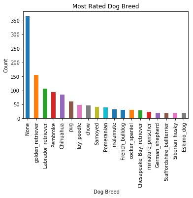

```python
# Histogram to visualize dog breeeds
dog_breed = twitter.groupby('dog_breed').filter(lambda x: len(x) >= 20)
dog_breed['dog_breed'].value_counts().plot(kind = 'bar')
plt.title('Most Rated Dog Breed')
plt.ylabel('Count')
plt.xlabel(' Dog Breed');
```

We can see that golden retriever is the most common breed, if we ignore the none rows.

1. Ratings over time

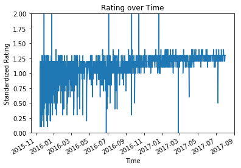

```python
# Line plot for standardized ratings over time

twitter.groupby('timestamp')['rating'].mean().plot(kind='line')
plt.ylim(0, 2)
plt.title('Rating over Time')
plt.xlabel('Time')
plt.ylabel('Standardized Rating')
plt.show;
```

We can see that there are many ratings below one, especially before 2016-11.